# lecture_geo

## Московские цены на аренду комнаты

#### Задача

- При поиске жилья одним из критериев может быть адекватность цены аренды, она не может быть слишком завышена или занижена, идеальный случай, когда она немного занижена. Чтобы найти адекватную стоимость сгенерим признаки, влияющие на конечную стоимость и построим модель, которая бы предсказывала бы ее.
- Было бы интересно оценить стоимость сдачи комнаты в ГЗ

Установим нужные нам пакеты

```python
!pip install shapely folium geopandas lightgbm tqdm shap geopy pyshp
```

```python
from tqdm import tqdm
import numpy as np
import pandas as pd
import geopandas as gpd
import folium
import matplotlib as mpl
import matplotlib.cm as cm
import matplotlib.pyplot as plt
pd.options.display.max_columns = 200
```

```python
df = pd.read_csv('flat_prices_room.csv.zip', compression='zip')
df.head(3)
```

```python
len(df)
```

```
3181
```

Параметры комнаты в Главном Здании МГУ

```python
gz_parameters = {
    'lat': 55.703672,
    'lon': 37.529788,
    'Дом': '9/30 Кирпичный',
    'Количество комнат': 1,
    'Метро': 'Университет (20 мин пешком)',
    'Можно с детьми/животными': np.nan,
    'Мусоропровод': 'Да',
    'Окна': 'Во двор',
    'Парковка': 'наземная',
    'Площадь комнат, м2': 10,
    'Площадь, м2': '10/4/0',
    'Ремонт': 'Косметический',
    'Санузел': 'Раздельный (1)',
    'Тип': 'Комната',
    'floor': 9,
    'max_floor': 30,
    'Холодильник': False,
    'Мебель в комнатах': True,
    'Мебель на кухне': False,
    'Ванна': False,
    'Интернет': True,
    'Телевизор': False,
    'Душевая кабина': True,
    'rooms': 1,
    'Изолированная': True,
    'room_area': 10,
    'total_area': 14,
    'long_rent': True,
    'Комунальные услуги': False,
    'Состав съемщиков': 'Любой',
    'ID  объявления':  'gz_room',
    'price': 15000
}
```

Добавим в общий датафрейм

```python
df = pd.concat([df, pd.DataFrame([gz_parameters])], sort=False, ignore_index=True)
```

```python
df = df[df['Тип'] == 'Комната']
```

Отфильтруем значения в которых нет координат

```python
df = df[~df['lat'].isnull()]
```

#### Для отображения геообъектов в jupyter notebook - folium

```python
center = {'lat': 55.756204, 'lon': 37.616675}
```

```python
map_folium = folium.Map(location=(center['lat'], center['lon']),
                        tiles='Stamen Toner',
                        zoom_start=11)
```

Пройдемся по 1000 случайным строчкам в датафрейме и создадим на основе их folium объекты CircleMarker и добавим их на карту При этом воспользуемся функциями для преобразования чисел в RGB цвет

```python
norm = mpl.colors.Normalize(vmin=0, vmax=50000)
cmap = cm.plasma
colormap= cm.ScalarMappable(norm=norm, cmap=cmap)
for ind, row in df.sample(1000).iterrows():
    folium.CircleMarker([row['lat'], row['lon']],
                        radius=7,
                        popup='{}'.format('<br>'.join(map(str, [row['price']]))),
                        color=mpl.colors.rgb2hex((colormap.to_rgba(row['price']))),
                        fill_color=mpl.colors.rgb2hex((colormap.to_rgba(row['price']))),
                        fill=True,
                        fill_opacity=0.9
                       ).add_to(map_folium)
map_folium
```

[interactive chart not shown]

#### Найдем расстояние каждой точки до центра

```python
from geopy import distance
df['distance_to_center'] = df.apply(lambda r: distance.distance((r['lat'], r['lon']),
                                                                (center['lat'], center['lon'])
                                                               ).meters, axis=1)
```

Отфильтруем удаленные объекта от центра Москвы

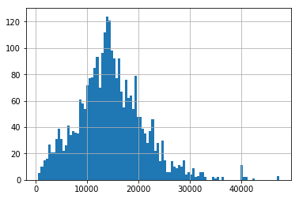

```python
df = df[df['distance_to_center'] < 5e4]
df['distance_to_center'].hist(bins=100)
df = df.reset_index(drop=True)
```

#### Извлечем признаки из сырых данных

```python
df['Дом'].value_counts().head()
```

```
2/5, Кирпичный    79
4/5, Кирпичный    72
3/5, Кирпичный    71
5/5, Кирпичный    68
4/9, Панельный    67
Name: Дом, dtype: int64
```

Извлечем материал стен

```python
df['wall_material'] = df['Дом'].str.split(',').str[1]
```

```python
df['Метро'].value_counts().head()
```

```
м. Выхино (15 мин на машине)      12
м. Выхино (15 мин пешком)         11
м. Выхино (10 мин на машине)      10
м. Отрадное (15 мин пешком)       10
м. Сходненская (15 мин пешком)    10
Name: Метро, dtype: int64
```

```python
df['metro_on_car'] = df['Метро'].str.contains('машине').astype(float)
df['metro_on_foot'] = df['Метро'].str.contains('пешком').astype(float)
df['minute_to_metro'] = df['Метро'].str.split('(').str[1].str.split(' ').str[0]
df['minute_to_metro'] = pd.to_numeric(df['minute_to_metro'], errors='coerce')
minutes_on_foot_vs_car = 5
df['minute_to_metro'] = df.apply(lambda r: r['minute_to_metro'] * minutes_on_foot_vs_car
                                 if r['metro_on_foot'] else r['minute_to_metro'], axis=1)
```

```python
df['Можно с детьми/животными'].value_counts()
```

```
Можно с детьми                       317
Можно с детьми, Можно с животными    206
Можно с животными                     80
Name: Можно с детьми/животными, dtype: int64
```

Извлечем остальные признаки из колонок

В поле "Балкон" содержится различные слова либо "Балкон" либо "Лоджия", вычленим от туда эти слова и сгенерим бинарный признак. То же самое с полем "Можно с детьми/животными" и "Окна"

```python
df['Балкон_Лоджия'] = df['Балкон'].str.contains('Лоджия').astype(float)
df['Балкон_Балкон'] = df['Балкон'].str.contains('Балкон').astype(float)

df['with_childs'] = df['Можно с детьми/животными'].str.contains('Можно с детьми').astype(float)
df['with_pets'] = df['Можно с детьми/животными'].str.contains('Можно с животными').astype(float)

df['windows_to_street'] = df['Окна'].str.contains('улицу').astype(float)
df['windows_to_courtyard'] = df['Окна'].str.contains('двор').astype(float)
```

```python
df['Мусоропровод'] = (df['Мусоропровод'] == 'Да').astype(float)
```

В названии ЖК присутсвует год постройки для новых ЖК

```python
df['building_year'] = pd.to_numeric(df['Название ЖК'].str.split(' ').str[-1], errors='coerce')
df['building_year'] = df['building_year']
```

Разобьем поле "Площадь" '10/10/10' на три

```python
for i in range(3):
    df[f'square_{i}'] = pd.to_numeric(df['Площадь, м2'].str.split('/').str[i], errors='coerce')
df['Площадь комнат, м2'] = pd.to_numeric(df['Площадь комнат, м2'], errors='coerce')
```

Заменим значения выпадающие из диапазона возможных

```python
df.loc[(df['Площадь комнат, м2'] > 300) | (df['Площадь комнат, м2'] < 0), 'Площадь комнат, м2'] = np.nan
```

```python
df['Парковка'].value_counts()
```

```
наземная          730
многоуровневая      7
подземная           7
Name: Парковка, dtype: int64
```

Преобразуем строковые категориальные признаки в число

```python
cat_features = ['Парковка', 'Санузел', 'wall_material', 'Состав съемщиков']
for col in cat_features:
    df[col] = df[col].astype('category').cat.codes
```

#### Построим модель на только что сгенеренных признаках

Отфильтруем таргет - цену от выбросов. Для борьбы с выбросами можно использовать также преобразование log(1 + x)

```python
df = df[(df['price'] < 40000) & (df['price'] > 5000)]
df = df.reset_index(drop=True)
```

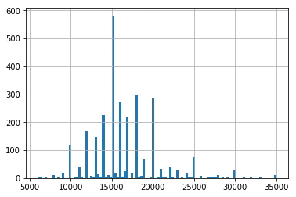

```python
df['price'].hist(bins=100)
```

Обучим lightgbm модель на основе сгенерированных признаков, в качества таргета возьмем цену. Разбивку на трейн и тест сделаем случайную с помощью функции train_test_split с размером теста 0.25 от величины целого датасета

```python
from sklearn.model_selection import train_test_split
import lightgbm as lgb
```

```python
trash_columns = ['ID  объявления', 'Адрес', 'Тип', 'Телефоны',
                 'Ссылка на объявление', 'Балкон', 'Лифт',
                 'Дом', 'Дополнительно', 'Можно с детьми/животными', 'Метро',
                 'Мусоропровод', 'Название ЖК', 'Количество комнат', 'Окна',
                 'Ремонт', 'Площадь, м2', 'Серия дома',
                 'Цена', 'url', 'Описание', 'lat', 'lon']
target = 'price'
```

```python
features = list(set(df.columns) - set(trash_columns + [target]))
train, test = train_test_split(df, random_state=1337)

lgb_data_train = lgb.Dataset(train[features], train[target])
lgb_data_test = lgb.Dataset(test[features], test[target])
params = {
    'objective':'regression',
    'metric': 'mae',
    'learning_rate': 0.05,
    'nthread': 1,
    'reg_lambda': 30
}


model = lgb.train(params, lgb_data_train,
                  valid_sets=[lgb_data_test, lgb_data_train],
                  categorical_feature=cat_features,
                  num_boost_round=3500,
                  early_stopping_rounds=100, verbose_eval=40)
```

```
Training until validation scores don't improve for 100 rounds.
[40]	training's l1: 2079.24	valid_0's l1: 2219.67
[80]	training's l1: 1846.6	valid_0's l1: 2141.77
[120]	training's l1: 1706.88	valid_0's l1: 2129.01
[160]	training's l1: 1592.23	valid_0's l1: 2130.78
[200]	training's l1: 1496.98	valid_0's l1: 2135.67
Early stopping, best iteration is:
[127]	training's l1: 1683.8	valid_0's l1: 2127.98
```

##### Цена сдачи однокомнатной квартиры в гз

```python
pred = model.predict(test[test['ID  объявления'] == 'gz_room'][features])
pred
```

```
array([ 16781.96461699])
```

Оценим влияние каждого фактора с помощью feature importance - количество узлов приходящихся на каждый признак

```python
(pd.DataFrame({'name': model.feature_name(),
              'importance': model.feature_importance()})
 .sort_values('importance', ascending=False)
 .head(10))
```

|  | name | importance |
| --- | --- | --- |
| 6 | distance_to_center | 676 |
| 26 | minute_to_metro | 472 |
| 2 | square_0 | 415 |
| 0 | square_1 | 406 |
| 22 | square_2 | 343 |
| 10 | max_floor | 242 |
| 15 | Высота_потолков,_м | 197 |
| 13 | floor | 159 |
| 8 | windows_to_street | 103 |
| 16 | Балкон_Балкон | 84 |

Также можно оценить более качественно влияние каждого их признаков с помощью библиотеки SHAP

[статья](http://papers.nips.cc/paper/7062-a-unified-approach-to-interpreting-model-predictions.pdf)

На графике ниже можно видеть влияние каждого признака на выход модели

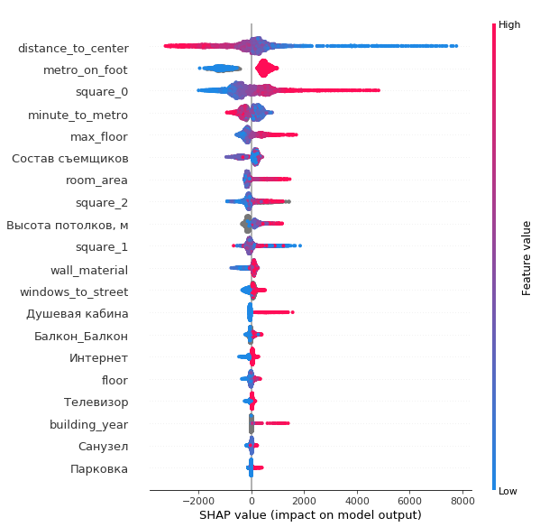

```python
import shap
explainer = shap.TreeExplainer(model)
shap_values = explainer.shap_values(df[features])
shap.summary_plot(shap_values, df[features])
```

## Добавим признаки связанные с ближайшими геообъектами

Для этого скачаем данные Open Street Maps

```python
%%bash
mkdir ../data
mkdir ../data/cent_fed
```

```python
%%bash
wget -O ../data/central-fed.shp.zip   http://download.geofabrik.de/russia/central-fed-district-latest-free.shp.zip
```

```python
%%bash
sudo apt install unzip
```

```python
%%bash
unzip ../data/central-fed.shp.zip -d ../data/cent_fed/
```

```python
%%bash
ls -l ../data/cent_fed/
```

Для поиска ближайших соседей переведем все координаты из долготы и широты в расстояния по долготе и широте от центра Москвы

```python
lat_meters = 111300
lon_meters = 57476
def center_lat_to_meter(lat):
    return (lat - center['lat']) * lat_meters

def center_lon_to_meter(lon):
    return (lon - center['lon']) * lon_meters
```

```python
df['lat_meter'] = df['lat'].apply(center_lat_to_meter)
df['lon_meter'] = df['lon'].apply(center_lon_to_meter)
```

формат этих файлов .shp, в них хранится информация о геометрии объекта, класс и название. Можно иттерироваться по этим объектам с помощью функции reader.iterShapeRecords() которая возвращает генератор. Каждый объект содержит два поля record и shаpe

```python
import shapefile
```

```python
reader = shapefile.Reader('../data/cent_fed/gis_osm_pois_free_1')
```

Пройдемся по всем записям и сохраним лишь те, что рассположены на расстоянии 40 км

```python
max_distance  = 40000
out = []
for point in reader.iterShapeRecords():
    lon, lat = np.mean(point.shape.points, axis=0)
    lat_meter =  center_lat_to_meter(lat)
    lon_meter = center_lon_to_meter(lon)
    if np.abs(lat_meter) > max_distance or np.abs(lon_meter) > max_distance :
        continue
    out.append({'category': point.record[2],
                'lat': lat,
                'lon': lon,
                'lat_meter': lat_meter,
                'lon_meter': lon_meter,
               })
```

```python
df_poi = pd.DataFrame(out)
```

```python
df_cafe = df_poi[df_poi['category'] == 'school']
```

```python
map_folium = folium.Map(location=(center['lat'], center['lon']),
                        tiles='Stamen Toner',
                        zoom_start=11)
for ind, row in df_cafe.iterrows():
    folium.CircleMarker([row['lat'], row['lon']],
                        radius=1,
                        fill=True,
                        fill_opacity=0.9
                       ).add_to(map_folium)
map_folium
```

[interactive chart not shown]

Для быстрого поиска ближайших объектов к определенной точки, создадим структуру данных KDTree и будем делать запросы к ней

```python
from scipy import spatial
```

```python
kdtree = spatial.KDTree(df_poi[['lat_meter', 'lon_meter']].values)
```

Первый элемет - расстояние, второй - индекс

```python
kdtree.query([55, 37], 4)
```

```
(array([ 20.77675998,  21.55709842,  21.76028261,  22.12623911]),
 array([47176, 47173, 47167, 47175]))
```

Объекты в радиусе

```python
kdtree.query_ball_point([55, 37], 30)
```

[34487, 47166, 47167, 47168, 47170, 47173, 47175, 47176, 47179, 47181, 47189]

Пройдемся по категориям, которые посчитали, что внесут вклад в уточнение стоимости и посчитаем средние расстояния до этих объектов среди 1 и 5 соседей и количество объектов в радиусе 500 и 1000 метров

```python
important_category_poi = ['cinema', 'supermarket', 'cafe', 'police',
                          'museum', 'fast_food', 'bank', 'beauty_shop',
                          'school']
```

```python
for cat in tqdm(important_category_poi):
    df_poi_cat = df_poi[df_poi['category'] == cat]
    df_poi_cat = df_poi_cat.reset_index(drop=True)
    kdtree = spatial.KDTree(df_poi_cat[['lat_meter', 'lon_meter']].values)
    distances = kdtree.query(df[['lat_meter', 'lon_meter']].values, 16)[0]
    for nearest in [1, 5]:
        df[f'distance_to_{cat}_between_{nearest}'] = np.mean(distances[:, :nearest], axis=1)

    for distance in [500, 1000]:
        nearests = kdtree.query_ball_point(df[['lat_meter', 'lon_meter']].values, distance)
        df[f'nearest_{cat}_within_{distance}'] = nearests
        df[f'nearest_{cat}_within_{distance}'] = df[f'nearest_{cat}_within_{distance}'].apply(len)
```

Снова обучим модель и посмотрим на сколько изменилось качество

```python
trash_columns += ['lat_meter', 'lon_meter']
```

```python
features = list(set(df.columns) - set(trash_columns + [target]))
```

```python
train, test = train_test_split(df, random_state=1337)

lgb_data_train = lgb.Dataset(train[features], train[target])
lgb_data_test = lgb.Dataset(test[features], test[target])
params = {
    'objective':'regression',
    'metric': 'mae',
    'learning_rate': 0.04,
    'nthread': 1,
    'reg_lambda': 30,
    'subsample': 0.9,
    'feature_fraction': 0.9
}

model = lgb.train(params, lgb_data_train,
                  valid_sets=[lgb_data_test, lgb_data_train],
                  categorical_feature=cat_features,
                  num_boost_round=3500,
                  early_stopping_rounds=100, verbose_eval=40)
```

```
Training until validation scores don't improve for 100 rounds.
[40]	training's l1: 2104.14	valid_0's l1: 2271.39
[80]	training's l1: 1793.72	valid_0's l1: 2150.86
[120]	training's l1: 1600.21	valid_0's l1: 2126.2
[160]	training's l1: 1448.29	valid_0's l1: 2122.23
[200]	training's l1: 1320.06	valid_0's l1: 2126.46
[240]	training's l1: 1208.89	valid_0's l1: 2127.37
Early stopping, best iteration is:
[170]	training's l1: 1414.83	valid_0's l1: 2120.45
```

```python
model.predict(test[test['ID  объявления'] == 'gz_room'][features])
```

```
array([ 17057.05962753])
```

```python
(pd.DataFrame({'name': model.feature_name(),
              'importance': model.feature_importance()})
 .sort_values('importance', ascending=False)
 .head(25))
```

|  | name | importance |
| --- | --- | --- |
| 8 | square_0 | 324 |
| 13 | distance_to_center | 319 |
| 54 | minute_to_metro | 220 |
| 0 | square_1 | 198 |
| 50 | distance_to_museum_between_5 | 186 |
| 43 | distance_to_supermarket_between_5 | 170 |
| 41 | square_2 | 164 |
| 14 | distance_to_cinema_between_5 | 160 |
| 23 | max_floor | 159 |
| 55 | distance_to_museum_between_1 | 155 |
| 47 | distance_to_police_between_5 | 155 |
| 45 | distance_to_police_between_1 | 145 |
| 2 | distance_to_school_between_5 | 134 |
| 5 | distance_to_school_between_1 | 133 |
| 25 | distance_to_cinema_between_1 | 130 |
| 40 | distance_to_fast_food_between_5 | 129 |
| 21 | distance_to_bank_between_1 | 123 |
| 3 | distance_to_fast_food_between_1 | 122 |
| 32 | Высота_потолков,_м | 119 |
| 70 | distance_to_supermarket_between_1 | 119 |
| 51 | distance_to_cafe_between_5 | 105 |
| 16 | distance_to_beauty_shop_between_1 | 102 |
| 17 | distance_to_cafe_between_1 | 100 |
| 27 | nearest_fast_food_within_1000 | 98 |
| 39 | nearest_bank_within_1000 | 96 |

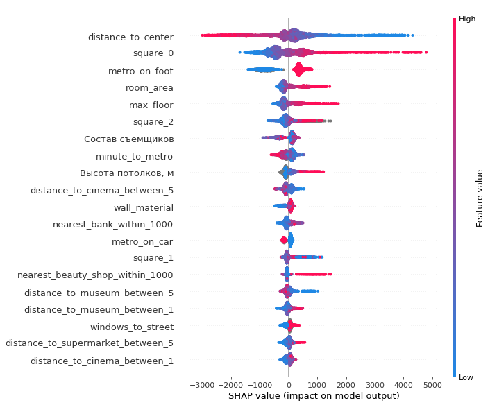

```python
explainer = shap.TreeExplainer(model)
shap_values = explainer.shap_values(df[features])
shap.summary_plot(shap_values, df[features])
```